# IMRR_Zacłona_Szmid

Weronika Zacłona

2026-10-27

# 1. Wprowadzenie

## 1.1. Cel i przedmiot analizy

Celem projektu jest porównanie poziomu i struktury ryzyka rynkowego akcji dwóch spółek notowanych na Giełdzie Papierów Wartościowych w Warszawie: CI Games oraz CD Projekt.

Wybór przedsiębiorstw działających w tej samej branży umożliwia ocenę, w jakim stopniu podobieństwo profilu działalności przekłada się na zbliżone charakterystyki ryzyka inwestycyjnego. Szczególną uwagę poświęcono zmienności stóp zwrotu, wrażliwości na zmiany szerokiego rynku oraz zagrożeniu wystąpienia znaczących strat.

Analiza opiera się na ilościowych miarach ryzyka rynkowego, w szczególności odchyleniu standardowym stóp zwrotu, współczynniku beta, Value at Risk (VaR) i Expected Shortfall (ES). Uzupełnieniem badania będzie ocena efektu dywersyfikacji oraz zastosowanie dodatkowych miar ryzyka.

## 1.2. Charakterystyka analizowanych spółek

### CI Games

CI Games to polskie przedsiębiorstwo działające na międzynarodowym rynku gier komputerowych, zajmujące się produkcją i wydawaniem gier wideo. Do najbardziej rozpoznawalnych marek spółki należą *Sniper Ghost Warrior* oraz *Lords of the Fallen*.

Działalność przedsiębiorstwa opiera się w dużej mierze na realizacji projektów, których wyniki finansowe zależą od powodzenia premier oraz zainteresowania odbiorców. Istotnymi czynnikami ryzyka są koszty produkcji, opóźnienia wydawnicze, reakcje graczy oraz niepewność dotycząca przyszłej sprzedaży.

Z perspektywy inwestora oznacza to potencjalną wrażliwość notowań na informacje dotyczące postępów produkcyjnych, zapowiedzi nowych gier i wyników sprzedażowych.

### CD Projekt

CD Projekt to polskie przedsiębiorstwo z branży gier komputerowych, znane przede wszystkim z serii *Wiedźmin* oraz gry *Cyberpunk 2077*. Spółka prowadzi działalność na rynku międzynarodowym, rozwijając własne marki i realizując wieloletnie projekty produkcyjne.

Istotnym elementem modelu biznesowego jest wykorzystanie rozpoznawalności posiadanych marek, które mogą generować przychody również po premierze gry. Jednocześnie długie cykle produkcyjne, wysokie nakłady inwestycyjne oraz oczekiwania rynku wobec kolejnych premier stanowią źródło niepewności.

Wycena giełdowa przedsiębiorstwa może być zatem kształtowana zarówno przez bieżące wyniki finansowe, jak i oczekiwania inwestorów dotyczące przyszłych projektów.

## 1.3. Uzasadnienie wyboru spółek

Wybór CI Games i CD Projekt wynika z połączenia podobieństwa branżowego z odmienną skalą działalności i charakterystyką realizowanych projektów.

Oba przedsiębiorstwa funkcjonują na globalnym rynku gier komputerowych i podlegają podobnym czynnikom zewnętrznym, takim jak zmiany koniunktury, preferencje konsumentów, konkurencja czy rozwój technologii. Jednocześnie różnią się rozpoznawalnością marek, skalą prowadzonych projektów oraz możliwościami finansowania działalności.

Takie zestawienie pozwala postawić pytanie badawcze:

**Czy akcje przedsiębiorstw należących do tej samej branży charakteryzują się podobnym poziomem ryzyka rynkowego, czy też różnice w skali działalności i modelu biznesowym znajdują odzwierciedlenie w ich profilach ryzyka?**

Przyjęto hipotezę badawczą, zgodnie z którą podobieństwo branżowe nie musi oznaczać zbliżonego poziomu ryzyka inwestycyjnego, a różnice między spółkami mogą ujawniać się szczególnie w zakresie zmienności stóp zwrotu i ryzyka specyficznego.

## 1.4. Zakres i założenia analizy

Analiza obejmuje dzienne notowania akcji CI Games i CD Projekt od 1 stycznia 2023 r. do 30 września 2026 r. Wybór okresu uzasadniają premiery *Phantom Liberty* (CD Projekt) oraz *Lords of the Fallen* (CI Games) w 2023 roku. Pozwala to porównać ryzyko inwestycyjne obu spółek przed ważnymi premierami oraz w kolejnych latach.

Jako przybliżenie portfela rynkowego przyjęto indeks WIG, umożliwiający ocenę wrażliwości akcji na zmiany szerokiego rynku oraz wyodrębnienie ryzyka systematycznego i specyficznego. Podstawowym horyzontem pomiaru ryzyka jest jedna sesja giełdowa, uzupełniona analizą dla dziesięciu sesji.

# 2. Dane i metodologia badania

## 2.1. Źródła i przygotowanie danych

```
## [1] 937
```

```
## [1] 937
```

```
## [1] "2023-01-02" "2026-09-30"
```

```
## [1] "2023-01-02" "2026-09-30"
```

```
##            CIG.WA.Close CIG.WA.Adjusted
## 2023-01-02        2.470           2.470
## 2023-01-03        2.555           2.555
## 2023-01-04        2.530           2.530
## 2023-01-05        2.520           2.520
## 2023-01-09        2.510           2.510
## 2023-01-10        2.530           2.530
```

```
##            CDR.WA.Close CDR.WA.Adjusted
## 2023-01-02       129.34        126.9491
## 2023-01-03       129.00        126.6154
## 2023-01-04       127.50        125.1431
## 2023-01-05       132.56        130.1096
## 2023-01-09       133.74        131.2678
## 2023-01-10       138.16        135.6061
```

Do analizy wykorzystano ceny skorygowane (*Adjusted Close*), czyli ceny akcji uwzględniające korekty związane ze zdarzeniami korporacyjnymi, takimi jak wypłaty dywidend czy podziały akcji. Ich zastosowanie ma na celu zapewnienie większej porównywalności notowań w czasie oraz ograniczenie wpływu technicznych zmian cen na obliczane stopy zwrotu i miary ryzyka.

## 2.2. Synchronizacja i wizualizacja danych

Dane obu spółek zsynchronizowano według wspólnych sesji giełdowych. Na potrzeby wizualizacji ceny akcji przeliczono względem ich wartości początkowych, przyjmując dla obu spółek umowną wartość 100. Pozwala to porównać procentowe zmiany cen niezależnie od ich poziomu nominalnego.

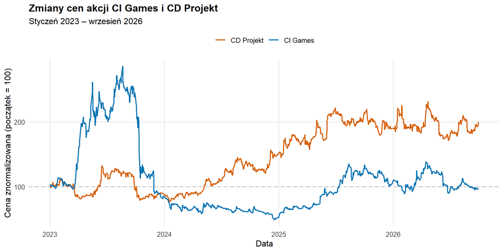

W analizowanym okresie notowania obu spółek wykazywały wyraźnie odmienne tendencje. Akcje CI Games charakteryzowały się szczególnie dużymi wahaniami w 2023 roku, kiedy po dynamicznym wzroście nastąpił gwałtowny spadek ich wartości. W kolejnych latach kurs utrzymywał się na relatywnie niższym poziomie, wykazując okresowe wzrosty.

Z kolei akcje CD Projekt, pomimo przejściowych spadków, od 2024 roku wykazywały wyraźną tendencję wzrostową. Pod koniec badanego okresu ich znormalizowana wartość była blisko dwukrotnie wyższa od początkowej, podczas gdy notowania CI Games powróciły w okolice poziomu wyjściowego.

## 2.3. Dzienne stopy zwrotu

Na podstawie cen skorygowanych obliczono dzienne proste stopy zwrotu, określające względną zmianę wartości akcji pomiędzy kolejnymi sesjami giełdowymi:

$$R_t = \frac{P_t - P_{t-1}}{P_{t-1}}$$

gdzie:

- $P_t$ – cena akcji w dniu $t$,
- $P_{t-1}$ – cena akcji z poprzedniej sesji giełdowej.

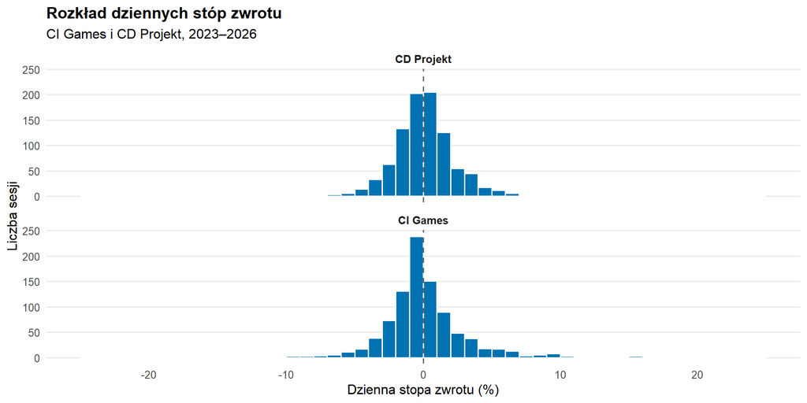

Rozkłady dziennych stóp zwrotu obu spółek wykazują największą koncentrację obserwacji w pobliżu zera. W przypadku CI Games widoczne jest większe rozproszenie wartości oraz występowanie bardziej skrajnych dodatnich stóp zwrotu. Rozkład CD Projekt jest natomiast bardziej skupiony wokół wartości centralnych.

Daty skrajnych dziennych stóp zwrotu

| Spółka | Rodzaj zmiany | Data | Stopa zwrotu (%) |
| --- | --- | --- | --- |
| CI Games | Najwiekszy spadek | 2023-10-16 | -24.93 |
| CI Games | Najwiekszy wzrost | 2024-05-06 | 24.32 |
| CD Projekt | Najwiekszy spadek | 2023-03-21 | -10.91 |
| CD Projekt | Najwiekszy wzrost | 2023-06-14 | 13.33 |

Gwałtowny spadek notowań CI Games z 16 października 2023 r. nastąpił bezpośrednio po premierze *Lords of the Fallen*, której towarzyszyły liczne problemy techniczne oraz negatywne opinie graczy. Rozczarowujący odbiór gry zwiększył obawy inwestorów dotyczące jej wyników sprzedażowych, co przyczyniło się do silnej przeceny akcji. Zdarzenie to stanowi przykład ryzyka specyficznego związanego z działalnością przedsiębiorstwa.

# 3. Analiza ryzyka według modelu Markowitza

## 3.1. Średnia stopa zwrotu i odchylenie standardowe

W modelu Markowitza ryzyko inwestycyjne mierzone jest wariancją lub odchyleniem standardowym stopy zwrotu. Im większe odchylenie standardowe, tym większa zmienność osiąganych stóp zwrotu.

Średnią dzienną stopę zwrotu oszacowano jako:

$$\bar{R} = \frac{1}{n}\sum_{t=1}^{n}R_t$$

Natomiast wariancję i odchylenie standardowe wyznaczono na podstawie wzorów:

$$s^2 = \frac{1}{n-1}\sum_{t=1}^{n}(R_t-\bar{R})^2$$

$$s = \sqrt{s^2}$$

gdzie $n$ oznacza liczbę obserwacji, a $\bar{R}$ średnią stopę zwrotu.

Podstawowe miary ryzyka akcji

| Spółka | Średnia dzienna stopa zwrotu (%) | Wariancja | Odchylenie standardowe (%) |
| --- | --- | --- | --- |
| CI Games | 0.056 | 0.001173 | 3.426 |
| CD Projekt | 0.101 | 0.000537 | 2.317 |

Akcje CI Games charakteryzowały się wyższym poziomem ryzyka, z odchyleniem standardowym wynoszącym 3,426%, wobec 2,317% dla CD Projekt. Jednocześnie CD Projekt osiągnął wyższą średnią dzienną stopę zwrotu (0,101% wobec 0,056%), wykazując korzystniejszą relację stopy zwrotu do ryzyka.

## 3.2. Korelacja stóp zwrotu i efekt dywersyfikacji

W celu zbadania zależności pomiędzy stopami zwrotu obu spółek wyznaczono współczynnik korelacji Pearsona.

Zależność między stopami zwrotu obu spółek

| Miara | Wartość |
| --- | --- |
| Korelacja Pearsona | 0.183080 |
| Kowariancja | 0.000145 |

Współczynnik korelacji Pearsona wyniósł 0,1831, co wskazuje na słabą dodatnią zależność między dziennymi stopami zwrotu obu spółek. Dodatnia kowariancja (0,000145) potwierdza kierunek tej współzmienności. Niska korelacja sugeruje możliwość ograniczenia ryzyka poprzez połączenie akcji CI Games i CD Projekt w jednym portfelu.

## 3.3. Ryzyko portfela dwuskładnikowego

W celu oceny efektu dywersyfikacji utworzono portfel składający się w 50% z akcji CI Games i w 50% z akcji CD Projekt. Ryzyko portfela oszacowano na podstawie odchylenia standardowego jego stopy zwrotu:

$$\sigma_p = \sqrt{w_1^2\sigma_1^2+w_2^2\sigma_2^2+
2w_1w_2\rho_{12}\sigma_1\sigma_2}$$

gdzie:

- $w_1$, $w_2$ – udziały akcji w portfelu,
- $\sigma_1$, $\sigma_2$ – odchylenia standardowe stóp zwrotu,
- $\rho_{12}$ – współczynnik korelacji stóp zwrotu obu spółek.

Porównanie ryzyka portfela z ryzykiem poszczególnych akcji pozwala ocenić korzyści wynikające z dywersyfikacji.

Porównanie ryzyka akcji i portfela 50/50

| Inwestycja | Średnia dzienna stopa zwrotu (%) | Odchylenie standardowe (%) |
| --- | --- | --- |
| CI Games | 0.056 | 3.426 |
| CD Projekt | 0.101 | 2.317 |
| Portfel 50/50 | 0.079 | 2.237 |

Portfel składający się w równych proporcjach z akcji CI Games i CD Projekt osiągnął średnią dzienną stopę zwrotu na poziomie 0,079% przy odchyleniu standardowym wynoszącym 2,237%. Ryzyko portfela okazało się niższe niż w przypadku każdej ze spółek osobno, co potwierdza występowanie efektu dywersyfikacji.

## 3.4. Portfel o minimalnej wariancji

W celu wyznaczenia struktury portfela o najniższym poziomie ryzyka przeanalizowano możliwe udziały akcji obu spółek przy założeniu braku krótkiej sprzedaży:

$$w_1 + w_2 = 1, \qquad w_1, w_2 \in [0, 1]$$

Dla portfela dwuskładnikowego odchylenie standardowe stopy zwrotu dane jest wzorem:

$$\sigma_p = \sqrt{w_1^2\sigma_1^2 + (1-w_1)^2\sigma_2^2 +
2w_1(1-w_1)\operatorname{Cov}(R_1, R_2)}$$

Wagę minimalizującą ryzyko wyznaczono numerycznie, obliczając odchylenie standardowe dla dyskretnej siatki wag udziału CI Games ($w_1 \in [0, 1]$ z krokiem $0{,}001$), a następnie znajdując indeks wartości minimalnej za pomocą funkcji `which.min()`.

Portfel o minimalnej wariancji

| Miara | Wartość |
| --- | --- |
| Udzial CI Games (%) | 27.600 |
| Udzial CD Projekt (%) | 72.400 |
| Srednia dzienna stopa zwrotu (%) | 0.089 |
| Odchylenie standardowe (%) | 2.071 |

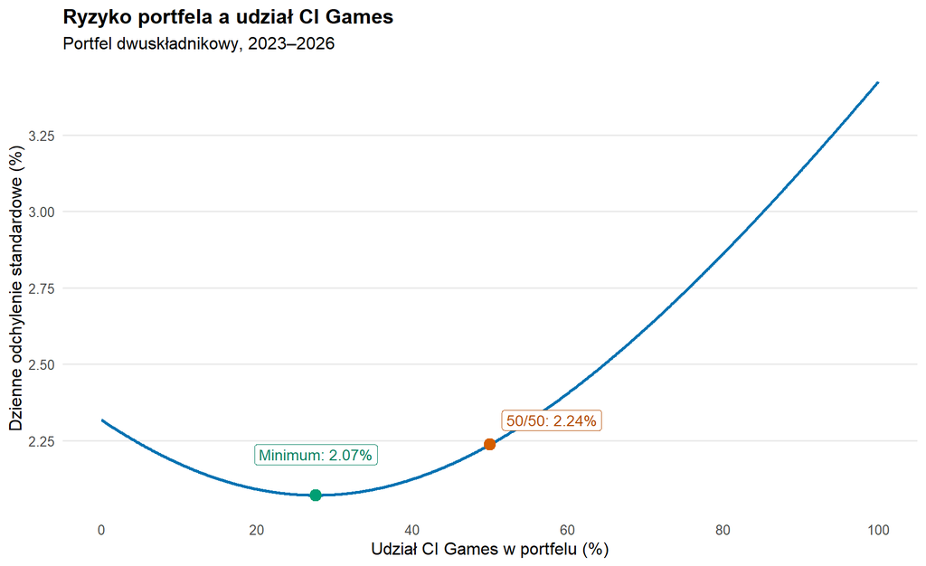

# 4. Model wyceny aktywów kapitałowych (CAPM)

## 4.1. Założenia modelu i dekompozycja ryzyka

W modelu CAPM (*Capital Asset Pricing Model*) wrażliwość stopy zwrotu akcji na zmiany szerokiego rynku (reprezentowanego przez indeks WIG) określa współczynnik beta:

$$\beta_i = \frac{\operatorname{Cov}(R_i, R_M)}{\sigma_M^2}$$

Model pozwala na dekompozycję całkowitej wariancji stóp zwrotu na ryzyko systematyczne (rynkowe) oraz ryzyko specyficzne (idiosynkratyczne):

$$\sigma_i^2 = \beta_i^2 \sigma_M^2 + \sigma_{\epsilon_i}^2$$

gdzie $|\beta_i|\sigma_M$ oznacza ryzyko systematyczne, a $\sigma_{\epsilon_i} = \sqrt{\sigma_i^2 - \beta_i^2\sigma_M^2}$ ryzyko specyficzne.

Efektywność inwestycji w ujęciu ex-post oceniono za pomocą wskaźników Sharpe’a, Treynora oraz alfy Jensena, przyjmując stopę wolną od ryzyka $r_f = 5{,}75\%$ rocznie.

## 4.2. Oszacowanie parametrów CAPM

Oszacowane parametry modelu CAPM i miary efektywności

| Spółka | Współczynnik Beta | Ryzyko sys. (%) | Ryzyko spec. (%) | Udział spec. (%) | Wskaźnik Sharpe’a | Wskaźnik Treynora | Alfa Jensena (%) |
| --- | --- | --- | --- | --- | --- | --- | --- |
| CI Games | 0.619 | 0.697 | 3.354 | 95.9 | 0.158 | 0.139 | -5.66 |
| CD Projekt | 0.830 | 0.935 | 2.120 | 83.7 | 0.539 | 0.239 | 0.70 |

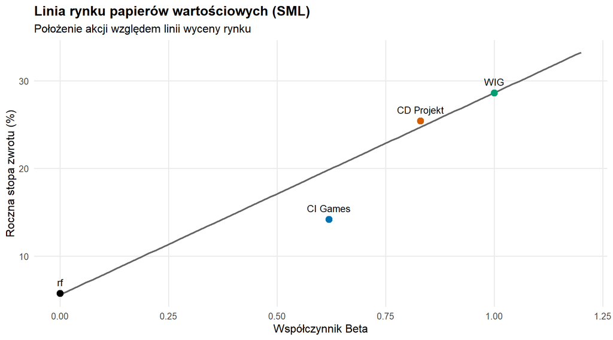

Współczynnik beta wyniósł 0,619 dla CI Games oraz 0,830 dla CD Projekt, co wskazuje na niższą wrażliwość notowań obu spółek na zmiany indeksu WIG w porównaniu z całym rynkiem. Dekompozycja ryzyka wykazała wyraźną dominację ryzyka specyficznego, które stanowi aż 95,9% całkowitej wariancji dla CI Games oraz 83,7% dla CD Projekt. Oznacza to, że wahania cen akcji w badanym okresie wynikały w przeważającej mierze ze zdarzeń wewnątrz spółek (premier gier), a nie z koniunktury na szerokim rynku.

CD Projekt osiągnął wyższe wartości miar efektywności: wskaźnik Sharpe’a wyniósł 0,539, wskaźnik Treynora 0,239, a roczna alfa Jensena 0,70%, co odpowiada położeniu spółki blisko Linii Rynku Papierów Wartościowych (SML). Dla CI Games wskaźniki te były znacznie niższe (Sharpe 0,158, Treynor 0,139 oraz ujemna alfa Jensena -5,66%). Położenie CI Games wyraźnie poniżej linii SML oznacza, że ze względu na załamanie notowań jesienią 2023 r. zrealizowana stopa zwrotu nie rekompensowała ponoszonego ryzyka rynkowego.

# 5. Zmienność w modelu Blacka–Scholesa

## 5.1. Oszacowanie zmienności historycznej

W modelu Blacka–Scholesa jednym z kluczowych parametrów jest zmienność ceny instrumentu bazowego, oznaczana symbolem $\sigma$. Określa ona skalę niepewności dotyczącej przyszłych zmian ceny i wpływa na wartość opcji.

Na potrzeby analizy oszacowano zmienność historyczną akcji CI Games i CD Projekt na podstawie dziennych logarytmicznych stóp zwrotu:

$$r_t = \ln\left(\frac{P_t}{P_{t-1}}\right)$$

Następnie obliczono odchylenie standardowe logarytmicznych stóp zwrotu i przeliczono je na zmienność roczną:

$$\sigma_{\mathrm{roczna}} = s_r\sqrt{252}$$

gdzie $s_r$ oznacza odchylenie standardowe dziennych logarytmicznych stóp zwrotu, a 252 przyjętą liczbę sesji giełdowych w roku. Otrzymana wartość stanowi historyczne oszacowanie zmienności, a nie zmienność implikowaną z cen opcji.

Historyczna zmienność akcji CI Games i CD Projekt

| Spółka | Zmienność dzienna (%) | Zmienność roczna (%) |
| --- | --- | --- |
| CI Games | 3.435 | 54.523 |
| CD Projekt | 2.311 | 36.682 |

Oszacowana roczna zmienność historyczna akcji CI Games wyniosła 54,523%, podczas gdy dla CD Projekt osiągnęła 36,682%. Oznacza to, że notowania CI Games charakteryzowały się znacznie większą zmiennością, co wskazuje na wyższy poziom niepewności związanej z inwestowaniem w akcje tej spółki. Wyniki są zgodne z wcześniejszą analizą Markowitza, w której CI Games również wykazywało większe odchylenie standardowe stóp zwrotu.

## 5.2. Zmienność historyczna w czasie

W celu zbadania zmian poziomu ryzyka w analizowanym okresie obliczono 30-sesyjną zmienność kroczącą logarytmicznych stóp zwrotu. Dla każdej sesji wyznaczono odchylenie standardowe stóp zwrotu z poprzednich 30 obserwacji, a następnie przeliczono je na skalę roczną.

Zastosowanie zmienności kroczącej pozwala zidentyfikować okresy podwyższonej niepewności oraz porównać stabilność zmienności obu spółek. Stanowi również uzupełnienie założenia o stałej zmienności przyjmowanego w klasycznym modelu Blacka–Scholesa.

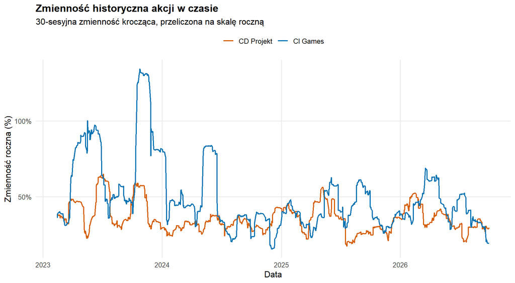

Analiza 30-sesyjnej zmienności kroczącej wykazała, że poziom ryzyka obu spółek zmieniał się w czasie. Szczególnie wysoką zmienność odnotowano w przypadku CI Games w 2023 roku, kiedy okresowo przekraczała ona 100% w skali rocznej. CD Projekt charakteryzował się na ogół niższą i bardziej stabilną zmiennością, choć również występowały okresy jej wzrostu. Wyniki wskazują, że założenie stałej zmienności przyjmowane w klasycznym modelu Blacka–Scholesa stanowi uproszczenie rzeczywistych warunków rynkowych.

# 6. Value at Risk (VaR)

## 6.1. Jednodniowy VaR – metoda historyczna

Value at Risk (VaR) jest miarą ryzyka określającą próg straty, który przy przyjętym modelu i poziomie ufności nie powinien zostać przekroczony w ustalonym horyzoncie inwestycyjnym.

W analizie zastosowano poziomy ufności 95% i 99% oraz horyzont jednej sesji giełdowej. VaR wyznaczono metodą symulacji historycznej, wykorzystując empiryczny rozkład dziennych prostych stóp zwrotu.

Dla poziomu ufności $c$ procentowy VaR obliczono jako:

$$VaR_c=-Q_{1-c}(R)$$

gdzie $Q_{1-c}(R)$ oznacza kwantyl rozkładu stóp zwrotu odpowiadający prawdopodobieństwu $1-c$.

Wyniki przedstawiono jako dodatnie wartości potencjalnej straty.

Historyczny jednodniowy Value at Risk

| Spółka | Poziom ufności | Jednodniowy VaR (%) |
| --- | --- | --- |
| CI Games | 95% | 4.145 |
| CD Projekt | 95% | 3.423 |
| CI Games | 99% | 8.582 |
| CD Projekt | 99% | 6.065 |

Historyczny jednodniowy VaR przy poziomie ufności 95% wyniósł 4,145% dla CI Games oraz 3,423% dla CD Projekt. Przy wyższym poziomie ufności, wynoszącym 99%, wartości wzrosły odpowiednio do 8,582% i 6,065%. Oznacza to, że w analizowanym okresie CI Games charakteryzowało się większym ryzykiem wystąpienia znacznych jednodniowych strat. Wzrost VaR wraz z poziomem ufności wskazuje na możliwość występowania strat wyraźnie większych niż te obserwowane przy standardowym progu 95%.

## 6.2. Jednodniowy VaR – metoda parametryczna

W celu porównania metod szacowania ryzyka wyznaczono jednodniowy VaR metodą parametryczną, przy założeniu normalnego rozkładu dziennych prostych stóp zwrotu.

VaR obliczono na podstawie średniej stopy zwrotu, odchylenia standardowego i odpowiedniego kwantyla standardowego rozkładu normalnego:

$$VaR_c=-\left(\bar{R}+z_{1-c}s\right)$$

gdzie $\bar{R}$ oznacza średnią dzienną stopę zwrotu, $s$ – odchylenie standardowe, a $z_{1-c}$ – kwantyl standardowego rozkładu normalnego odpowiadający prawdopodobieństwu $1-c$.

Obliczenia przeprowadzono dla poziomów ufności 95% i 99%, zachowując jednodniowy horyzont inwestycyjny.

Parametryczny jednodniowy Value at Risk

| Spółka | Poziom ufności | Jednodniowy VaR (%) |
| --- | --- | --- |
| CI Games | 95% | 5.578 |
| CD Projekt | 95% | 3.711 |
| CI Games | 99% | 7.913 |
| CD Projekt | 99% | 5.290 |

Parametryczny jednodniowy VaR dla CI Games wyniósł 5,578% przy poziomie ufności 95% oraz 7,913% przy poziomie 99%. W przypadku CD Projekt wartości te wyniosły odpowiednio 3,711% i 5,290%. Wyniki potwierdzają wyższe ryzyko jednodniowych strat dla CI Games. Porównanie z metodą historyczną wskazuje, że przy poziomie ufności 95% metoda parametryczna daje wyższe oszacowania VaR dla obu spółek, natomiast przy poziomie 99% niższe. Sugeruje to, że założenie normalności rozkładu może nie odzwierciedlać w pełni ryzyka skrajnych strat.

## 6.3. Porównanie metod szacowania VaR

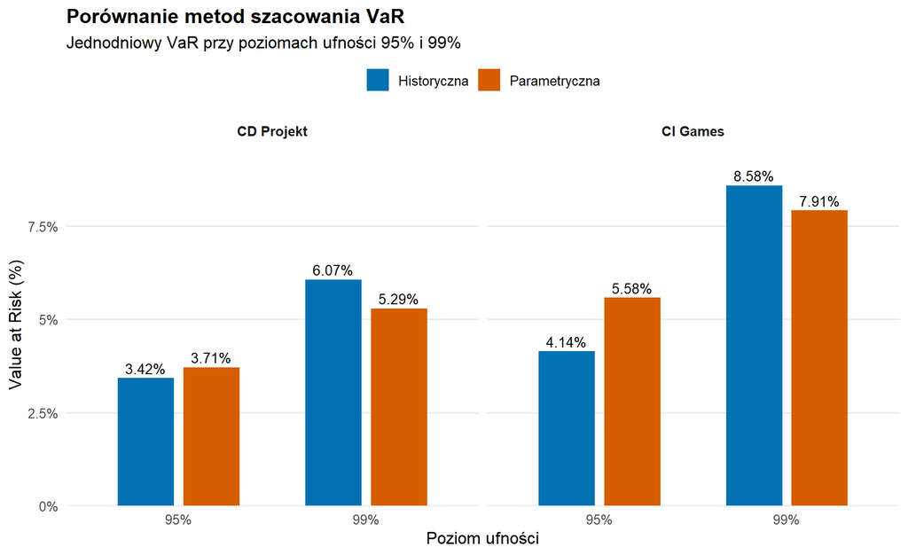

## 6.4. Value at Risk dla horyzontu 10 sesji giełdowych

W celu oceny wpływu horyzontu inwestycyjnego na poziom ryzyka wyznaczono VaR dla okresu 10 sesji giełdowych, przy poziomach ufności 95% i 99%.

W metodzie historycznej wykorzystano 10-sesyjne proste stopy zwrotu, obliczone jako:

$$R_t^{(10)}=\frac{P_t}{P_{t-10}}-1$$

W metodzie parametrycznej zastosowano skalowanie średniej stopy zwrotu i odchylenia standardowego przy założeniu niezależnych dziennych stóp zwrotu o stałych parametrach:

$$VaR_{c,10}=-\left(10\bar R+z_{1-c}s\sqrt{10}\right)$$

Podejście parametryczne stanowi przybliżenie oparte na normalnym rozkładzie dziennych prostych stóp zwrotu i addytywnym modelu stopy zwrotu w czasie. Obie metody pozwalają porównać ryzyko inwestycji utrzymywanej przez 10 sesji.

Value at Risk dla horyzontu 10 sesji

| Spółka | Poziom ufności | Metoda | 10-sesyjny VaR (%) |
| --- | --- | --- | --- |
| CI Games | 95% | Historyczna | 12.719 |
| CD Projekt | 95% | Historyczna | 10.147 |
| CI Games | 99% | Historyczna | 28.335 |
| CD Projekt | 99% | Historyczna | 17.459 |
| CI Games | 95% | Parametryczna | 17.255 |
| CD Projekt | 95% | Parametryczna | 11.045 |
| CI Games | 99% | Parametryczna | 24.638 |
| CD Projekt | 99% | Parametryczna | 16.039 |

Wydłużenie horyzontu inwestycyjnego z jednej do 10 sesji wiązało się ze wzrostem oszacowanego VaR dla obu spółek. Najwyższe ryzyko odnotowano dla CI Games, dla którego historyczny VaR przy poziomie ufności 99% wyniósł 28,335%, wobec 17,459% dla CD Projekt. Metoda parametryczna dała w tych przypadkach niższe oszacowania, odpowiednio 24,638% i 16,039%. Wyniki wskazują, że wydłużenie okresu utrzymywania akcji zwiększa skalę potencjalnych strat, a przy wysokim poziomie ufności metoda parametryczna może nie uwzględniać w pełni ryzyka skrajnych zmian cen.

# 7. Expected Shortfall (ES)

## 7.1. Jednodniowy Expected Shortfall – metoda historyczna

Expected Shortfall (ES) jest miarą ryzyka określającą oczekiwaną wielkość straty w najgorszej części rozkładu stóp zwrotu. W przeciwieństwie do Value at Risk uwzględnia nie tylko próg straty, lecz również wielkość strat występujących poza tym progiem.

W analizie wyznaczono jednodniowy historyczny ES dla poziomów ufności 95% i 99%, wykorzystując empiryczny rozkład prostych stóp zwrotu.

ES zdefiniowano jako średnią wartość strat w najgorszym udziale $1-c$ rozkładu stóp zwrotu:

$$ES_c=-\frac{1}{1-c}\int_0^{1-c}Q_u(R)\,du$$

gdzie $Q_u(R)$ oznacza kwantyl rozkładu stóp zwrotu na poziomie $u$, natomiast $c$ oznacza przyjęty poziom ufności.

W obliczeniach zastosowano historyczny estymator ES oparty na średniej najniższych stóp zwrotu, z uwzględnieniem częściowej obserwacji na granicy ogona rozkładu.

Historyczny jednodniowy Expected Shortfall

| Spółka | Poziom ufności | Jednodniowy ES (%) |
| --- | --- | --- |
| CI Games | 95% | 7.397 |
| CD Projekt | 95% | 5.005 |
| CI Games | 99% | 14.223 |
| CD Projekt | 99% | 7.836 |

Historyczny jednodniowy Expected Shortfall dla CI Games wyniósł 7,397% przy poziomie ufności 95% oraz 14,223% przy poziomie 99%. Dla CD Projekt wartości te były niższe i wyniosły odpowiednio 5,005% oraz 7,836%. Szczególnie duża różnica występuje przy poziomie 99%, gdzie przeciętna strata w 1% najgorszych przypadków jest w CI Games niemal dwukrotnie wyższa niż w CD Projekt.

## 7.2. Porównanie Value at Risk i Expected Shortfall

W celu porównania ryzyka skrajnych strat zestawiono jednodniowe wartości historycznego VaR i ES.

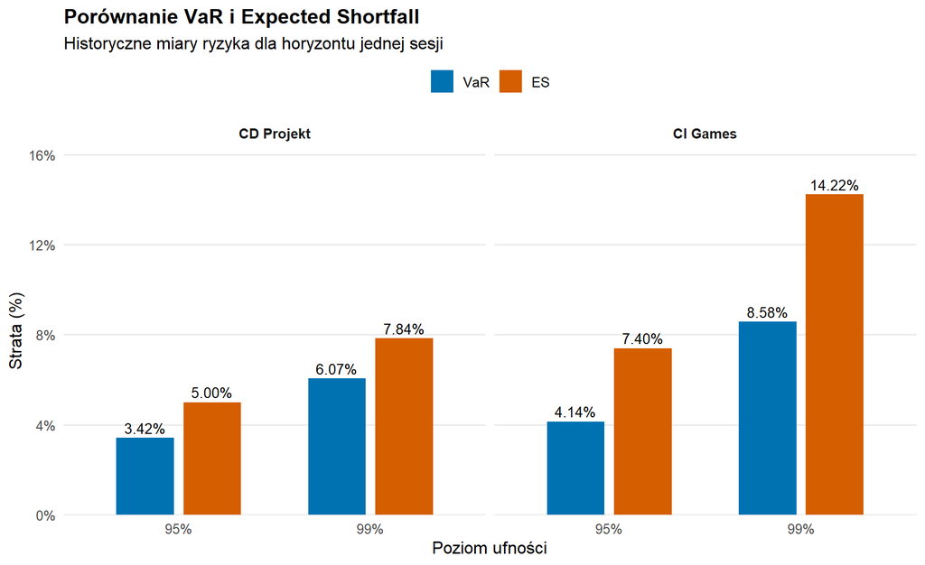

## 7.3. Ryzyko skrajnych strat w portfelach inwestycyjnych

W celu oceny wpływu dywersyfikacji na ryzyko skrajnych strat porównano historyczne wartości VaR i ES dla pojedynczych akcji oraz dwóch portfeli: o równych udziałach i minimalnej wariancji.

Dzienne stopy zwrotu portfeli obliczono jako średnie ważone stóp zwrotu CI Games i CD Projekt:

$$R_{p,t}=w_1R_{1,t}+w_2R_{2,t}$$

gdzie $w_1$ i $w_2$ oznaczają udziały poszczególnych akcji.

Dla obu portfeli zastosowano wagi ustalone na podstawie pełnego okresu badania. Następnie wyznaczono jednodniowe VaR i ES metodą historyczną przy poziomie ufności 95% i 99%. Porównanie ma charakter retrospektywny i nie stanowi oceny skuteczności strategii inwestycyjnej poza próbą.

Historyczne VaR i ES dla akcji oraz portfeli

| Inwestycja | Poziom ufności | VaR (%) | ES (%) |
| --- | --- | --- | --- |
| CI Games | 95% | 4.145 | 7.397 |
| CD Projekt | 95% | 3.423 | 5.005 |
| Portfel 50/50 | 95% | 3.191 | 4.881 |
| Portfel min. wariancji | 95% | 3.025 | 4.600 |
| CI Games | 99% | 8.582 | 14.223 |
| CD Projekt | 99% | 6.065 | 7.836 |
| Portfel 50/50 | 99% | 4.998 | 8.210 |
| Portfel min. wariancji | 99% | 5.612 | 6.968 |

# 8. Dodatkowe miary ryzyka

## 8.1. Maksymalne obsunięcie kapitału (Maximum Drawdown)

Maksymalne obsunięcie kapitału (*Maximum Drawdown*, MDD) określa największy procentowy spadek wartości inwestycji od lokalnego szczytu do kolejnego dołka w danym okresie:

$$MDD = \min_{t \in [0, T]} \left( \frac{V_t - \max_{s \le t} V_s}{\max_{s
\le t} V_s} \right)$$

Wskaźnik ten informuje o największej historycznej stracie, jaką poniósłby inwestor kupujący walor w najmniej korzystnym momencie (na lokalnym szczycie). MDD wyznaczono dla pojedynczych spółek oraz dla obu analizowanych portfeli.

Maksymalne obsunięcie kapitału w okresie 2023–2026

| Inwestycja | Maximum Drawdown (%) |
| --- | --- |
| CI Games | -82.75 |
| CD Projekt | -41.65 |
| Portfel 50/50 | -59.71 |
| Portfel min. wariancji | -50.48 |

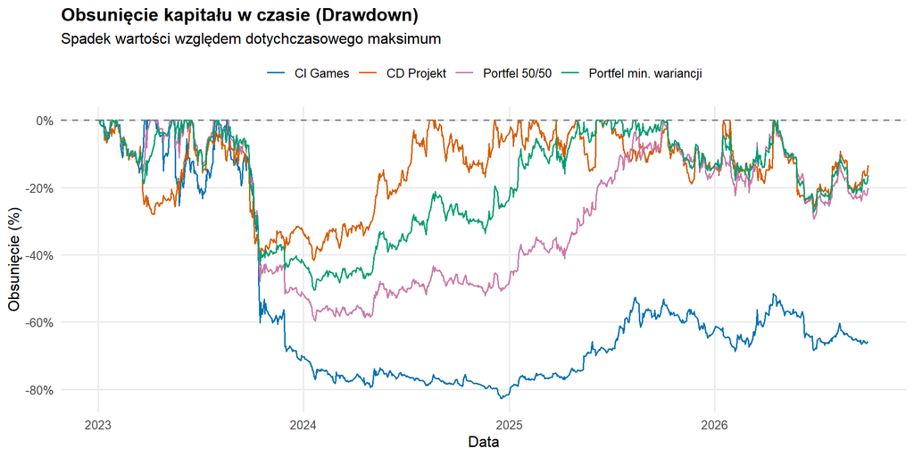

W przypadku CD Projekt maksymalne obsunięcie wyniosło -41,65% i miało charakter przejściowy. Przecena po premierze dodatku Phantom Liberty wynikała głównie z realizacji zysków przez inwestorów po wcześniejszych wzrostach. Pozytywne recenzje oraz długofalowa sprzedaż pozwoliły spółce w latach 2024–2025 całkowicie odrobić ten spadek i wyznaczyć nowe szczyty notowań, co na wykresie obrazują powroty linii do poziomu 0%.

Dywersyfikacja pozwoliła wyraźnie ograniczyć skalę obsunięcia kapitału w porównaniu z samodzielnym utrzymywaniem akcji CI Games. W portfelu o równych udziałach MDD wyniosło -59,71%, natomiast w portfelu minimalnej wariancji -50,48%. Wysoki udział CD Projekt w portfelu minimalnej wariancji sprawił, że portfel znacznie łagodniej odczuł załamanie kursu CI Games i szybciej odzyskiwał wartość.

## 8.2. Testowanie wsteczne Value at Risk (Backtesting)

W celu weryfikacji trafności wyznaczania Value at Risk przeprowadzono testowanie wsteczne (*backtesting*) w kroczącym oknie o długości 252 sesji (jeden rok giełdowy).

Dla każdej sesji $t$ oszacowano jednodniowy VaR na poziomie ufności 95% na podstawie poprzednich 252 sesji, a następnie sprawdzono, czy zrealizowana strata $L_t = -R_t$ przekroczyła wyznaczony próg:

$$I_t = \begin{cases} 1, & \text{gdy } L_t > VaR_{0{,}05, t} \\ 0,
& \text{w przeciwnym wypadku} \end{cases}$$

Badanie przeprowadzono dla metody historycznej oraz parametrycznej. Poprawnie skalibrowany model powinien generować przekroczenia na poziomie zbliżonym do teoretycznych 5% sesji testowych.

Wyniki testowania wstecznego 1-dniowego VaR (poziom ufności 95%)

| Spółka | Metoda VaR | Liczba sesji testowych | Oczekiwana liczba błędów | Rzeczywista liczba błędów | Wskaźnik przekroczeń (%) |
| --- | --- | --- | --- | --- | --- |
| CI Games | Historyczna | 684 | 34.2 | 29 | 4.24 |
| CI Games | Parametryczna | 684 | 34.2 | 17 | 2.49 |
| CD Projekt | Historyczna | 684 | 34.2 | 32 | 4.68 |
| CD Projekt | Parametryczna | 684 | 34.2 | 21 | 3.07 |

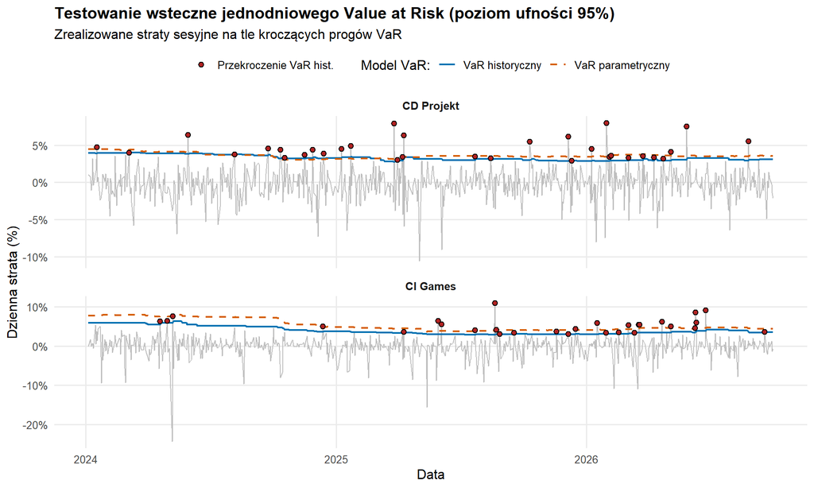

W badaniu testowania wstecznego na próbie 684 sesji oczekiwana liczba przekroczeń progu 95% wynosiła 34,2 sesji (5%). Metoda historyczna wykazała wysoką trafność szacowania ryzyka – odnotowano 29 przekroczeń dla CI Games (wskaźnik 4,24%) oraz 32 przekroczenia dla CD Projekt (4,68%), co jest wartością bardzo bliską teoretycznemu założeniu.

# 9. Podsumowanie i wnioski końcowe

Przeprowadzona analiza pozwoliła jednoznacznie potwierdzić przyjętą hipotezę badawczą: przynależność spółek do tej samej branży nie przesądza o zbliżonym poziomie ani profilu ryzyka inwestycyjnego. Mimo że zarówno CI Games, jak i CD Projekt funkcjonują w sektorze gier komputerowych i w podobnym czasie wprowadzały na rynek kluczowe tytuły, odmienna skala ich działalności, rozpoznawalność posiadanych marek oraz zróżnicowanie źródeł przychodów przełożyły się na fundamentalnie różne zachowanie notowań.

Główna różnica między spółkami ujawniła się w odporności na materializację ryzyka specyficznego, które w obu przypadkach dominowało nad wpływem szerokiego rynku. W przypadku CI Games model oparty na pojedynczych dużych produkcjach sprawił, że niepowodzenie premierowe doprowadziło do długotrwałego załamania wyceny oraz drastycznego wzrostu zagrożenia skrajnymi stratami, za które inwestorzy nie otrzymali adekwatnej premii. Z kolei CD Projekt, dysponujący silnymi markami o ugruntowanej pozycji globalnej, potraktował popremierową przecenę jedynie jako przejściową korektę, wykazując znacznie większą dojrzałość rynkową i zdolność do szybkiej odbudowy kapitału.

Badanie dowiodło również, że dywersyfikacja portfelowa zachowuje wysoką skuteczność nawet przy łączeniu podmiotów z tego samego sektora gospodarki. Ze względu na niezależność cykli produkcyjnych i premierowych stopy zwrotu obu spółek cechowały się bardzo słabym powiązaniem, co umożliwiło stworzenie portfela o wskaźnikach zmienności niższych niż dla jakiejkolwiek pojedynczej spółki składowej. Odpowiednia alokacja pozwoliła wyeliminować znaczną część ryzyka specyficznego, skutecznie zabezpieczając inwestora przed dotkliwymi skutkami załamania kursu pojedynczego emitenta.